# Project: Investigate a Dataset (No-show appointments)

- Introduction
- Data Wrangling
- Exploratory Data Analysis
- Conclusions

## Introduction

This worksheet will explore the dataset of medical appointments in Brazil and is focused on the question of whether patients show up for their appointment. the dataset contains 14 columns including the patient’s no-show status, it consists of 110527 entries. we will explore the data, wrangle, clean, and try to understand the data using summary statistics and visualizations, as couple of questions and try to find answers. The first question will be focusing on the period between scheduling day and appointment day and if this affects the patient no-show status. The second questions will be regarding if elements such as [Scholarship, Age, sms_received] affect their status.

## Data Wrangling

> In this section we will be importing the necessary libraries and requirements, load the data and check for any duplicates, Null, nonscience data, and have an overview of the data and prepare it for the next step.

### General Properties

#### Import the required libraries.

```python
import numpy as np
import pandas as pd
import matplotlib.pyplot as plt
import seaborn as sns
%matplotlib inline
```

#### Load the Data

```python
df = pd.read_csv('noshowappointments.csv')
```

#### Explore the data

```python
df.head()
```

|  | PatientId | AppointmentID | Gender | ScheduledDay | AppointmentDay | Age | Neighbourhood | Scholarship | Hipertension | Diabetes | Alcoholism | Handcap | SMS_received | No-show |
| --- | --- | --- | --- | --- | --- | --- | --- | --- | --- | --- | --- | --- | --- | --- |
| 0 | 2.987250e+13 | 5642903 | F | 2016-04-29T18:38:08Z | 2016-04-29T00:00:00Z | 62 | JARDIM DA PENHA | 0 | 1 | 0 | 0 | 0 | 0 | No |
| 1 | 5.589978e+14 | 5642503 | M | 2016-04-29T16:08:27Z | 2016-04-29T00:00:00Z | 56 | JARDIM DA PENHA | 0 | 0 | 0 | 0 | 0 | 0 | No |
| 2 | 4.262962e+12 | 5642549 | F | 2016-04-29T16:19:04Z | 2016-04-29T00:00:00Z | 62 | MATA DA PRAIA | 0 | 0 | 0 | 0 | 0 | 0 | No |
| 3 | 8.679512e+11 | 5642828 | F | 2016-04-29T17:29:31Z | 2016-04-29T00:00:00Z | 8 | PONTAL DE CAMBURI | 0 | 0 | 0 | 0 | 0 | 0 | No |
| 4 | 8.841186e+12 | 5642494 | F | 2016-04-29T16:07:23Z | 2016-04-29T00:00:00Z | 56 | JARDIM DA PENHA | 0 | 1 | 1 | 0 | 0 | 0 | No |

```python
df.describe()
```

|  | PatientId | AppointmentID | Age | Scholarship | Hipertension | Diabetes | Alcoholism | Handcap | SMS_received |
| --- | --- | --- | --- | --- | --- | --- | --- | --- | --- |
| count | 1.105270e+05 | 1.105270e+05 | 110527.000000 | 110527.000000 | 110527.000000 | 110527.000000 | 110527.000000 | 110527.000000 | 110527.000000 |
| mean | 1.474963e+14 | 5.675305e+06 | 37.088874 | 0.098266 | 0.197246 | 0.071865 | 0.030400 | 0.022248 | 0.321026 |
| std | 2.560949e+14 | 7.129575e+04 | 23.110205 | 0.297675 | 0.397921 | 0.258265 | 0.171686 | 0.161543 | 0.466873 |
| min | 3.921784e+04 | 5.030230e+06 | -1.000000 | 0.000000 | 0.000000 | 0.000000 | 0.000000 | 0.000000 | 0.000000 |
| 25% | 4.172614e+12 | 5.640286e+06 | 18.000000 | 0.000000 | 0.000000 | 0.000000 | 0.000000 | 0.000000 | 0.000000 |
| 50% | 3.173184e+13 | 5.680573e+06 | 37.000000 | 0.000000 | 0.000000 | 0.000000 | 0.000000 | 0.000000 | 0.000000 |
| 75% | 9.439172e+13 | 5.725524e+06 | 55.000000 | 0.000000 | 0.000000 | 0.000000 | 0.000000 | 0.000000 | 1.000000 |
| max | 9.999816e+14 | 5.790484e+06 | 115.000000 | 1.000000 | 1.000000 | 1.000000 | 1.000000 | 4.000000 | 1.000000 |

```python
df.shape
```

```
(110527, 14)
```

##### check for null values

```python
df.isnull().sum()
```

```
PatientId         0
AppointmentID     0
Gender            0
ScheduledDay      0
AppointmentDay    0
Age               0
Neighbourhood     0
Scholarship       0
Hipertension      0
Diabetes          0
Alcoholism        0
Handcap           0
SMS_received      0
No-show           0
dtype: int64
```

the dataset looks like it dosent have any null values

```python
df.dtypes
```

```
PatientId         float64
AppointmentID       int64
Gender             object
ScheduledDay       object
AppointmentDay     object
Age                 int64
Neighbourhood      object
Scholarship         int64
Hipertension        int64
Diabetes            int64
Alcoholism          int64
Handcap             int64
SMS_received        int64
No-show            object
dtype: object
```

#### Let's Explore some variables

```python
df['Handcap'].value_counts()
```

```
0    108286
1      2042
2       183
3        13
4         3
Name: Handcap, dtype: int64
```

```python
df['SMS_received'].value_counts()
```

```
0    75045
1    35482
Name: SMS_received, dtype: int64
```

```python
df['Scholarship'].value_counts()
```

```
0    99666
1    10861
Name: Scholarship, dtype: int64
```

```python
df['No-show'].value_counts()
```

```
No     88208
Yes    22319
Name: No-show, dtype: int64
```

The values seem to be confusing, No means showed, thus we can conclude that who already showed are more than no_show

# Data Cleaning

#### now lets see a histogram for the numeric variables.

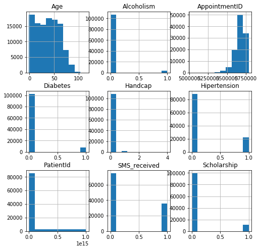

```python
df.hist(figsize=(8,8));
```

According to the histograms we can figure out few things:

> Age is sekewed to the right which means we have more patients younger than 50. several binary columns such as Alcoholism, Diabetes , SMS_received, Scholarship, and Hipertension.

```python
df.head()
```

|  | PatientId | AppointmentID | Gender | ScheduledDay | AppointmentDay | Age | Neighbourhood | Scholarship | Hipertension | Diabetes | Alcoholism | Handcap | SMS_received | No-show |
| --- | --- | --- | --- | --- | --- | --- | --- | --- | --- | --- | --- | --- | --- | --- |
| 0 | 2.987250e+13 | 5642903 | F | 2016-04-29T18:38:08Z | 2016-04-29T00:00:00Z | 62 | JARDIM DA PENHA | 0 | 1 | 0 | 0 | 0 | 0 | No |
| 1 | 5.589978e+14 | 5642503 | M | 2016-04-29T16:08:27Z | 2016-04-29T00:00:00Z | 56 | JARDIM DA PENHA | 0 | 0 | 0 | 0 | 0 | 0 | No |
| 2 | 4.262962e+12 | 5642549 | F | 2016-04-29T16:19:04Z | 2016-04-29T00:00:00Z | 62 | MATA DA PRAIA | 0 | 0 | 0 | 0 | 0 | 0 | No |
| 3 | 8.679512e+11 | 5642828 | F | 2016-04-29T17:29:31Z | 2016-04-29T00:00:00Z | 8 | PONTAL DE CAMBURI | 0 | 0 | 0 | 0 | 0 | 0 | No |
| 4 | 8.841186e+12 | 5642494 | F | 2016-04-29T16:07:23Z | 2016-04-29T00:00:00Z | 56 | JARDIM DA PENHA | 0 | 1 | 1 | 0 | 0 | 0 | No |

#### let's dig deeper in Age variable.

```python
df['Age'].unique()
```

```
array([ 62,  56,   8,  76,  23,  39,  21,  19,  30,  29,  22,  28,  54,
        15,  50,  40,  46,   4,  13,  65,  45,  51,  32,  12,  61,  38,
        79,  18,  63,  64,  85,  59,  55,  71,  49,  78,  31,  58,  27,
         6,   2,  11,   7,   0,   3,   1,  69,  68,  60,  67,  36,  10,
        35,  20,  26,  34,  33,  16,  42,   5,  47,  17,  41,  44,  37,
        24,  66,  77,  81,  70,  53,  75,  73,  52,  74,  43,  89,  57,
        14,   9,  48,  83,  72,  25,  80,  87,  88,  84,  82,  90,  94,
        86,  91,  98,  92,  96,  93,  95,  97, 102, 115, 100,  99,  -1],
      dtype=int64)
```

Age has value of -1 which is not correct, so let's drop rows with values less than 0

```python
for i in range(0,len(df)):
    if df['Age'][i] < 0:
        df.drop(labels= i, axis = 0, inplace= True)
```

```python
df['Age'].unique()
```

```
array([ 62,  56,   8,  76,  23,  39,  21,  19,  30,  29,  22,  28,  54,
        15,  50,  40,  46,   4,  13,  65,  45,  51,  32,  12,  61,  38,
        79,  18,  63,  64,  85,  59,  55,  71,  49,  78,  31,  58,  27,
         6,   2,  11,   7,   0,   3,   1,  69,  68,  60,  67,  36,  10,
        35,  20,  26,  34,  33,  16,  42,   5,  47,  17,  41,  44,  37,
        24,  66,  77,  81,  70,  53,  75,  73,  52,  74,  43,  89,  57,
        14,   9,  48,  83,  72,  25,  80,  87,  88,  84,  82,  90,  94,
        86,  91,  98,  92,  96,  93,  95,  97, 102, 115, 100,  99],
      dtype=int64)
```

```python
df.describe()
```

|  | PatientId | AppointmentID | Age | Scholarship | Hipertension | Diabetes | Alcoholism | Handcap | SMS_received |
| --- | --- | --- | --- | --- | --- | --- | --- | --- | --- |
| count | 1.105260e+05 | 1.105260e+05 | 110526.000000 | 110526.000000 | 110526.000000 | 110526.000000 | 110526.000000 | 110526.000000 | 110526.000000 |
| mean | 1.474934e+14 | 5.675304e+06 | 37.089219 | 0.098266 | 0.197248 | 0.071865 | 0.030400 | 0.022248 | 0.321029 |
| std | 2.560943e+14 | 7.129544e+04 | 23.110026 | 0.297676 | 0.397923 | 0.258266 | 0.171686 | 0.161543 | 0.466874 |
| min | 3.921784e+04 | 5.030230e+06 | 0.000000 | 0.000000 | 0.000000 | 0.000000 | 0.000000 | 0.000000 | 0.000000 |
| 25% | 4.172536e+12 | 5.640285e+06 | 18.000000 | 0.000000 | 0.000000 | 0.000000 | 0.000000 | 0.000000 | 0.000000 |
| 50% | 3.173184e+13 | 5.680572e+06 | 37.000000 | 0.000000 | 0.000000 | 0.000000 | 0.000000 | 0.000000 | 0.000000 |
| 75% | 9.438963e+13 | 5.725523e+06 | 55.000000 | 0.000000 | 0.000000 | 0.000000 | 0.000000 | 0.000000 | 1.000000 |
| max | 9.999816e+14 | 5.790484e+06 | 115.000000 | 1.000000 | 1.000000 | 1.000000 | 1.000000 | 4.000000 | 1.000000 |

no-show is confusing so let's rename it to be show and change values from no, yes to 1,0.

```python
df.rename(columns={'No-show': 'show'}, inplace=True)
```

```python
df['show'].replace(['No','Yes'],[1,0], inplace = True)
```

Now 1 means showed, 0 means no-show

```python
df.duplicated().sum()
```

```
0
```

Our initial check for the data we can't find duplicates, however we could have duplicate bookings but with different time or appointment id, thus we will have to stratify these variables and double check duplicates.

Let's convert ScheduledDay and AppointmentDay from string to datetime and remove hours to have only the full date.

```python
df['ScheduledDay']=pd.to_datetime(df['ScheduledDay']).dt.strftime('%Y-%m-%d')
```

```python
df['AppointmentDay']=pd.to_datetime(df['AppointmentDay']).dt.strftime('%Y-%m-%d')
```

now let's create new variable for the waiting days by substract ScheduledDay from AppointmentDay

```python
df['waiting_days']= (pd.to_datetime(df['AppointmentDay']) - pd.to_datetime(df['ScheduledDay'])).dt.days
```

```python
df['waiting_days'].unique()
```

```
array([  0,   2,   3,   1,   4,   9,  29,  10,  23,  11,  18,  17,  14,
        28,  24,  21,  15,  16,  22,  43,  30,  31,  42,  32,  56,  45,
        46,  39,  37,  38,  44,  50,  60,  52,  53,  65,  67,  91,  66,
        84,  78,  87, 115, 109,  63,  70,  72,  57,  58,  51,  59,  41,
        49,  73,  64,  20,  33,  34,   6,  35,  36,  12,  13,  40,  47,
         8,   5,   7,  25,  26,  48,  27,  19,  61,  55,  62, 176,  54,
        77,  69,  83,  76,  89,  81, 103,  79,  68,  75,  85, 112,  -1,
        80,  86,  98,  94, 142, 155, 162, 169, 104, 133, 125,  96,  88,
        90, 151, 126, 127, 111, 119,  74,  71,  82, 108, 110, 102, 122,
       101, 105,  92,  97,  93, 107,  95,  -6, 139, 132, 179, 117, 146,
       123], dtype=int64)
```

we have some invalid data that gives us negative numbers, lets check them

```python
(df[df['waiting_days'] < 0])
```

|  | PatientId | AppointmentID | Gender | ScheduledDay | AppointmentDay | Age | Neighbourhood | Scholarship | Hipertension | Diabetes | Alcoholism | Handcap | SMS_received | show | waiting_days |
| --- | --- | --- | --- | --- | --- | --- | --- | --- | --- | --- | --- | --- | --- | --- | --- |
| 27033 | 7.839273e+12 | 5679978 | M | 2016-05-10 | 2016-05-09 | 38 | RESISTÊNCIA | 0 | 0 | 0 | 0 | 1 | 0 | 0 | -1 |
| 55226 | 7.896294e+12 | 5715660 | F | 2016-05-18 | 2016-05-17 | 19 | SANTO ANTÔNIO | 0 | 0 | 0 | 0 | 1 | 0 | 0 | -1 |
| 64175 | 2.425226e+13 | 5664962 | F | 2016-05-05 | 2016-05-04 | 22 | CONSOLAÇÃO | 0 | 0 | 0 | 0 | 0 | 0 | 0 | -1 |
| 71533 | 9.982316e+14 | 5686628 | F | 2016-05-11 | 2016-05-05 | 81 | SANTO ANTÔNIO | 0 | 0 | 0 | 0 | 0 | 0 | 0 | -6 |
| 72362 | 3.787482e+12 | 5655637 | M | 2016-05-04 | 2016-05-03 | 7 | TABUAZEIRO | 0 | 0 | 0 | 0 | 0 | 0 | 0 | -1 |

These rows give us AppointmentDay before ScheduledDay, they are invalid so let's drop them.

```python
df.drop((df[df['waiting_days'] < 0]).index, inplace = True)
```

```python
(df[df['waiting_days'] < 0])
```

|  | PatientId | AppointmentID | Gender | ScheduledDay | AppointmentDay | Age | Neighbourhood | Scholarship | Hipertension | Diabetes | Alcoholism | Handcap | SMS_received | show | waiting_days |
| --- | --- | --- | --- | --- | --- | --- | --- | --- | --- | --- | --- | --- | --- | --- | --- |

```python
df.shape
```

```
(110521, 15)
```

#### Now lets check again for the duplicated rows

```python
df.columns
```

```
Index(['PatientId', 'AppointmentID', 'Gender', 'ScheduledDay',
       'AppointmentDay', 'Age', 'Neighbourhood', 'Scholarship', 'Hipertension',
       'Diabetes', 'Alcoholism', 'Handcap', 'SMS_received', 'show',
       'waiting_days'],
      dtype='object')
```

```python
df['AppointmentID'].shape
```

```
(110521,)
```

AppointmentID is unique for each entry so let's not include the AppointmentID and keep everything else

```python
df.duplicated(subset=['PatientId','Gender', 'ScheduledDay','AppointmentDay',
                      'Age', 'Neighbourhood', 'Scholarship', 'Hipertension','show','waiting_days']).sum()
```

```
5599
```

let's drop the duplicates

```python
df.drop_duplicates(subset=['PatientId','Gender', 'ScheduledDay','AppointmentDay','Age',
                           'Neighbourhood', 'Scholarship', 'Hipertension','show','waiting_days'], inplace= True)
```

```python
df.duplicated(subset=['PatientId','Gender', 'ScheduledDay','AppointmentDay',
                      'Age', 'Neighbourhood', 'Scholarship', 'Hipertension','show','waiting_days']).sum()
```

```
0
```

## Exploratory Data Analysis

> Now that we have trimmed and cleaned your data,let's explore and visualize the data, as questions and answer them through analysis, visualizations and ststistics.

### First let's chech our dependent variable ('Show')

```
The total No_shows are 20.0 %
```

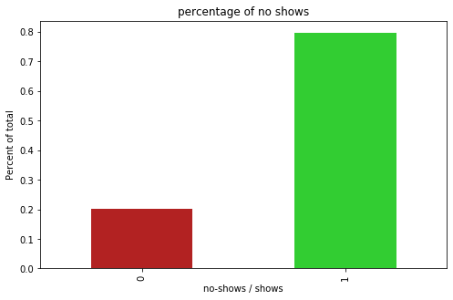

```python
colors = ('firebrick', 'limegreen')
total_number = df['show'].count()
percentage= df.groupby('show').count()['PatientId'] / total_number
percentage.plot.bar(color = colors ,figsize= (8,5));
plt.title('percentage of no shows')
plt.xlabel('no-shows / shows')
plt.ylabel('Percent of total');
print('The total No_shows are {} %'.format(percentage[0].round(2)*100))
```

The total number of no shows representing only 20% of overall data. now let's explore the correlation between numberic variables to understand more.

```python
correlation = df.corr()
correlation.style.background_gradient(cmap='coolwarm').set_precision(2)
```

|  | PatientId | AppointmentID | Age | Scholarship | Hipertension | Diabetes | Alcoholism | Handcap | SMS_received | show | waiting_days |
| --- | --- | --- | --- | --- | --- | --- | --- | --- | --- | --- | --- |
| PatientId | 1 | 0.003 | -0.0041 | -0.0021 | -0.0054 | 0.0027 | 0.0073 | -0.0068 | -0.0081 | 0.0025 | -0.00088 |
| AppointmentID | 0.003 | 1 | -0.018 | 0.022 | 0.015 | 0.024 | 0.027 | 0.014 | -0.26 | 0.16 | -0.77 |
| Age | -0.0041 | -0.018 | 1 | -0.094 | 0.51 | 0.29 | 0.091 | 0.079 | 0.012 | 0.059 | 0.033 |
| Scholarship | -0.0021 | 0.022 | -0.094 | 1 | -0.022 | -0.025 | 0.035 | -0.008 | 0.0013 | -0.028 | -0.03 |
| Hipertension | -0.0054 | 0.015 | 0.51 | -0.022 | 1 | 0.43 | 0.087 | 0.082 | -0.011 | 0.037 | -0.02 |
| Diabetes | 0.0027 | 0.024 | 0.29 | -0.025 | 0.43 | 1 | 0.023 | 0.059 | -0.018 | 0.016 | -0.028 |
| Alcoholism | 0.0073 | 0.027 | 0.091 | 0.035 | 0.087 | 0.023 | 1 | 0.0045 | -0.018 | -0.0069 | -0.032 |
| Handcap | -0.0068 | 0.014 | 0.079 | -0.008 | 0.082 | 0.059 | 0.0045 | 1 | -0.024 | 0.0087 | -0.019 |
| SMS_received | -0.0081 | -0.26 | 0.012 | 0.0013 | -0.011 | -0.018 | -0.018 | -0.024 | 1 | -0.13 | 0.4 |
| show | 0.0025 | 0.16 | 0.059 | -0.028 | 0.037 | 0.016 | -0.0069 | 0.0087 | -0.13 | 1 | -0.18 |
| waiting_days | -0.00088 | -0.77 | 0.033 | -0.03 | -0.02 | -0.028 | -0.032 | -0.019 | 0.4 | -0.18 | 1 |

from the above correlation map we can see that waiting_days has the negative correlation with show, let's see if it really impact the no_show or not?

### Q1: Does waiting_days impact the no_show patients?

```python
showed = df[df['show']==1]
no_show = df[df['show']==0]
```

creating the average waiting days for patients based on their no_show status

```python
mean_watiting_showed = showed['waiting_days'].mean()
mean_waiting_no_show=no_show['waiting_days'].mean()
```

```
The mean of waiting days for patients who showed is: 8.85 days
The mean of waiting days for patients who did not show is: 15.8 days
```

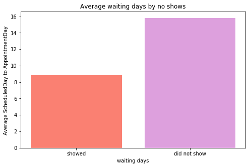

```python
fig, ax = plt.subplots(figsize=(8,5))
locations = [1, 2]
means = [mean_watiting_showed, mean_waiting_no_show]
labels = ['showed', 'did not show']
colors = ['salmon', 'plum']
plt.bar(locations, means, tick_label=labels, color= colors)
plt.title('Average waiting days by no shows')
plt.xlabel('waiting days')
plt.ylabel('Average ScheduledDay to AppointmentDay ');
print('The mean of waiting days for patients who showed is: {} days'.format(round(mean_watiting_showed,2)),
      '\nThe mean of waiting days for patients who did not show is: {} days'.format(round(mean_waiting_no_show,2)))
```

The average of patients who showed for their appointment is 8.85 days, while the average of patients who did not show is almost the double by 15.8, which means that there is a correlation between waiting days and the no show, the longer the waiting time the greater of no show to be happening.

### Q2: How patients' characteristics may impact their decision?

#### Let's start by check how the age impact our no-show

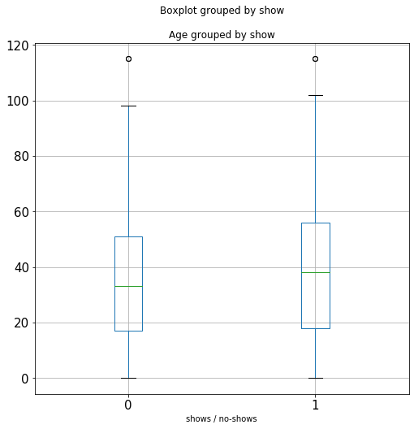

```python
df.boxplot(column=['Age'], by=['show'], fontsize=15, figsize=(8, 8));
plt.title('Age grouped by show')
plt.xlabel('shows / no-shows');
```

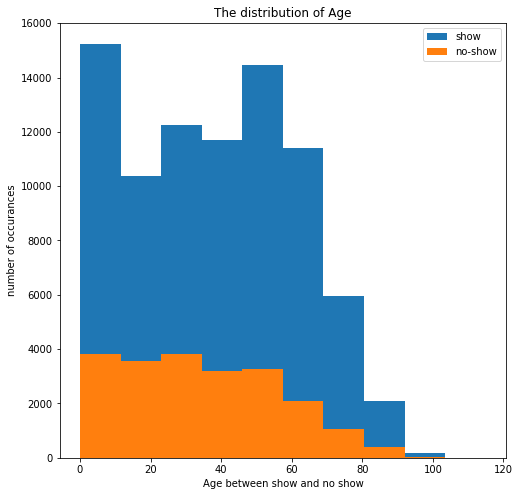

```python
ax= showed['Age'].hist(figsize= (8,8))
ax= no_show['Age'].hist(figsize= (8,8))
ax.set_title('The distribution of Age')
ax.set_xlabel('Age between show and no show')
ax.set_ylabel('number of occurances');
plt.legend(['show', 'no-show'])
ax.grid()
```

```python
df.groupby('show')['Age'].median()
```

```
show
0    33
1    38
Name: Age, dtype: int64
```

The Age of showed patients are slightly higher than those who did now, boxplot shows outliers thus we choose to calculate the median for more precision, the median shows only 5 years difference between the two groups

#### Now let's check if the gender impact their decision.

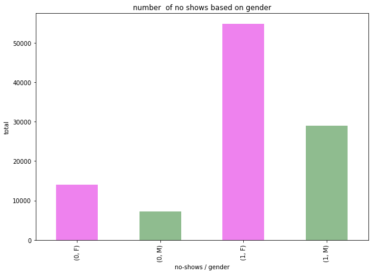

```python
colors = ['violet', 'darkseagreen']
G_group = df.groupby(['show','Gender'])['Gender'].count()
G_group.plot.bar(color = colors, figsize= (10,7));
plt.title('number  of no shows based on gender')
plt.xlabel('no-shows / gender')
plt.ylabel('total');
```

Clearly, we can see that the number of female is higher the male, therefore this chart can only tell us there is more female in our dataset, to investigate the gender based on no-shows w will have to use the proportion within each group

|  | Age |
| --- | --- |
| count | 2.000000 |
| mean | 52461.000000 |
| std | 22975.313534 |
| min | 36215.000000 |
| 25% | 44338.000000 |
| 50% | 52461.000000 |
| 75% | 60584.000000 |
| max | 68707.000000 |

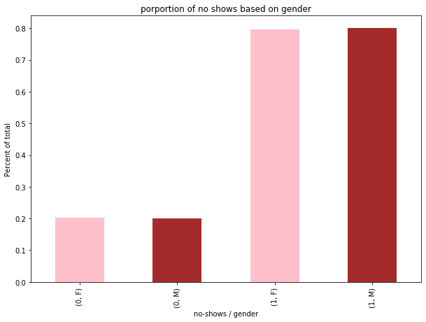

```python
colors = ['pink', 'brown']
total =df.groupby(['Gender']).count()['Age']
G_group = df.groupby(['show','Gender'])['Gender'].count() / total;
G_group.plot.bar(color = colors ,figsize= (10,7));
plt.title('porportion of no shows based on gender')
plt.xlabel('no-shows / gender')
plt.ylabel('Percent of total');
pd.DataFrame(total.describe())
```

```python
pd.DataFrame(G_group)
```

| show | Gender | 0 |
| --- | --- | --- |
| 0 | F | 0.203575 |
|  | M | 0.200414 |
| 1 | F | 0.796425 |
|  | M | 0.799586 |

surprisingly, we can tell both proportion are the same, there is no difference between male and female

#### Now its time to explore our third variable, which is the Scholarship

[output not shown]

[figure not shown]

```python
fig, ax = plt.subplots(figsize=(8,5))
locations = [0, 1]
colors = ['darkgreen','olive']
labels=['Scholarship','No-Scholarship']
m_Scholarship = df["Scholarship"].value_counts()
plt.bar(locations,m_Scholarship, tick_label=labels, color= colors)
plt.title('number of patients grouped by Scholarship');
```

The patients that enrolled in the scholarship program are fewer than the patients that don't have Scholarship

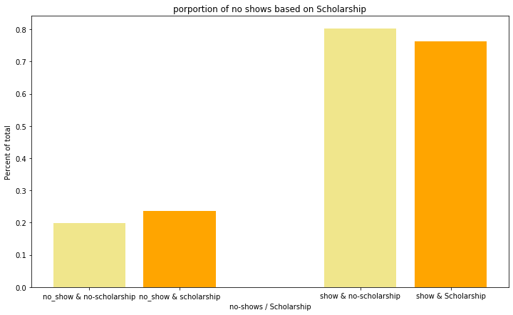

```python
fig, ax = plt.subplots(figsize=(12,7))
colors = ['khaki', 'orange']
total =df.groupby(['Scholarship']).count()['Age']
locations = [0,1,3,4]
labels = ['no_show & no-scholarship', 'no_show & scholarship', 'show & no-scholarship','show & Scholarship']
group = df.groupby(['show','Scholarship'])['Scholarship'].count() / total
plt.bar(locations, group, tick_label=labels, color= colors)
plt.title('porportion of no shows based on Scholarship')
plt.xlabel('no-shows / Scholarship')
plt.ylabel('Percent of total');
```

#### let's analyze the sms received impact

```python
df['SMS_received'].value_counts()
```

```
0    69982
1    34940
Name: SMS_received, dtype: int64
```

the number of patients who received sms are almost half of the patients who did not.

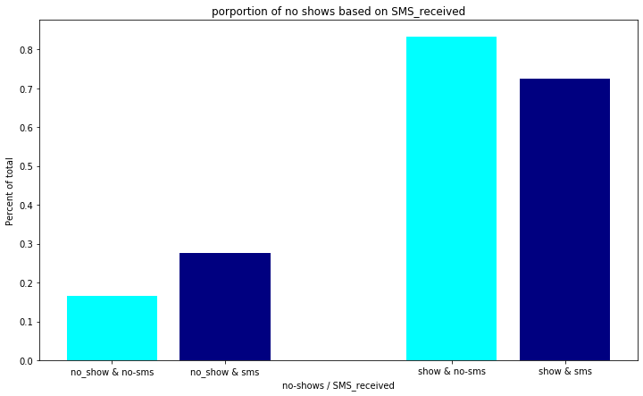

```python
fig, ax = plt.subplots(figsize=(12,7))
colors = ['aqua', 'navy']
total =df.groupby(['SMS_received']).count()['PatientId']
locations = [0,1,3,4]
labels = ['no_show & no-sms', 'no_show & sms', 'show & no-sms','show & sms']
group = df.groupby(['show','SMS_received'])['SMS_received'].count() / total
plt.bar(locations, group, tick_label=labels, color= colors)
plt.title('porportion of no shows based on SMS_received')
plt.xlabel('no-shows / SMS_received')
plt.ylabel('Percent of total');
```

## Conclusions

We analyzed waiting days, age, gender, Scholarship, and SMS received variables, the impact of each variable is different on no-show therefore to have a more robust conclusion we will run Ordinary Least Squares test for our variables to test their goodness.

```python
import statsmodels.api as sm
from statsmodels.formula.api import ols

result = ols('show ~ waiting_days+Age+Scholarship+SMS_received+Gender',data=df).fit()
print(result.params)
print(result.summary())
```

```
Intercept       0.821854
Gender[T.M]     0.000787
waiting_days   -0.004183
Age             0.001085
Scholarship    -0.036768
SMS_received   -0.055205
dtype: float64
                            OLS Regression Results
==============================================================================
Dep. Variable:                   show   R-squared:                       0.042
Model:                            OLS   Adj. R-squared:                  0.042
Method:                 Least Squares   F-statistic:                     916.4
Date:                Sat, 03 Apr 2021   Prob (F-statistic):               0.00
Time:                        03:21:17   Log-Likelihood:                -50981.
No. Observations:              104922   AIC:                         1.020e+05
Df Residuals:                  104916   BIC:                         1.020e+05
Df Model:                           5
Covariance Type:            nonrobust
================================================================================
                   coef    std err          t      P>|t|      [0.025      0.975]
--------------------------------------------------------------------------------
Intercept        0.8219      0.003    290.360      0.000       0.816       0.827
Gender[T.M]      0.0008      0.003      0.304      0.761      -0.004       0.006
waiting_days    -0.0042   8.69e-05    -48.165      0.000      -0.004      -0.004
Age              0.0011    5.3e-05     20.471      0.000       0.001       0.001
Scholarship     -0.0368      0.004     -8.883      0.000      -0.045      -0.029
SMS_received    -0.0552      0.003    -19.589      0.000      -0.061      -0.050
==============================================================================
Omnibus:                    19798.549   Durbin-Watson:                   1.816
Prob(Omnibus):                  0.000   Jarque-Bera (JB):            33653.609
Skew:                          -1.383   Prob(JB):                         0.00
Kurtosis:                       3.208   Cond. No.                         159.
==============================================================================

Warnings:
[1] Standard Errors assume that the covariance matrix of the errors is correctly specified.
```

The model explains the week realtion of most of the variables and no-show, the Adj. R-squared: values of 0.042 prove most of our analyzed variables have a slight impact on patients' no-show

## Limitations

> While analyzing the dataset we found out that the dataset contains of 5599 records out of 110527 duplicates but with different appointment ID and, that could give result in inaccurate results that might affect our understanding of the data.  
> another important point was some rows shows appointment day before the scheduling day, that can be a result of many things such as a manual input, we could find these rows because they were not correct however some other rows could have the same problem with wrong dates but could not be found because appointment day might be still in the acceptable range.

```python
time_of_data = pd.to_datetime(df['AppointmentDay'].max())- pd.to_datetime(df['AppointmentDay'].min())
print(str(time_of_data)[:6])
```

```
40 day
```

> The data size of 110527 entries and 14 variables are fairly good to analyze the data, however if we take a closer look at the appointment day we can notice that the data was collected in 40 days which might not be representative for the whole population, different times of the year might be better for our analysis.

# References

> https://stackoverflow.com  
> https://matplotlib.org  
> https://www.geeksforgeeks.org  
> https://pandas.pydata.org